# Clustering

←Back to the bookChapter 114 · Clustering

Chapter 114 · Clustering

Clustering

Discovering the natural groups in unlabeled e-commerce customers with K-means, hierarchical clustering (dendrograms), and DBSCAN, choosing the number of clusters with the elbow and silhouette methods, and profiling each segment into a business strategy, all library-first with scikit-learn and scipy, and heavily visual.

Statistics, Data Science and AI: A Visual Handbook · John Fisher · 2026

# Clustering: finding groups with no labels

Supervised learning had an answer key. Clustering does not: we hand the algorithm unlabeled data and ask it to *discover* the natural groups. This notebook segments e-commerce customers three ways, **K-means**, **hierarchical** (with a dendrogram), and **DBSCAN**, and shows how to choose the number of clusters with the **elbow** and **silhouette** methods. Library-first with `scikit-learn` and `scipy`.

```python
import numpy as np, pandas as pd, matplotlib.pyplot as plt
import seaborn as sns   # seaborn = high-level statistical plots (heatmaps, pairplots, count/bar plots)
from matplotlib.colors import ListedColormap
EM="#4338ca"; DEEP="#3730a3"; LIGHT="#c7d2fe"; INK="#1a2138"; GRID="#e6e9f2"; RED="#ef4444"; AMBER="#d97706"; GREEN="#059669"; BLUE="#2563eb"; PUR="#9333ea"; GREY="#94a3b8"; SLATE="#475569"; ORG="#4338ca"; CYAN="#0891b2"
plt.rcParams.update({"figure.facecolor":"white","axes.facecolor":"white","figure.dpi":110,"font.size":11,
   "axes.edgecolor":GRID,"axes.grid":True,"grid.color":GRID,"axes.axisbelow":True,"axes.spines.top":False,
   "axes.spines.right":False,"axes.titlesize":12,"axes.titleweight":"bold","legend.frameon":False})
sns.set_style("whitegrid")
BASE="https://raw.githubusercontent.com/johnfisher-ai/Statistics-Data-Science-AI-Visual-Book/main/data/"
```

```python
from sklearn.preprocessing import StandardScaler
from sklearn.cluster import KMeans, AgglomerativeClustering, DBSCAN
from sklearn.metrics import silhouette_score
from scipy.cluster.hierarchy import linkage, dendrogram
pd.set_option('display.max_columns', 30)
```

DEMO 1 · UNLABELED DATA

Four features, no answer key

Load customers and standardize, scale matters for distance.

```python
try: df = pd.read_excel('../../data/ch114_shoppers.xlsx', sheet_name='Data')
except FileNotFoundError: df = pd.read_excel(BASE + 'ch114_shoppers.xlsx', sheet_name='Data')
feat = ['annual_income_k','spending_score','age','web_visits_mo']
X = df[feat]
Xs = StandardScaler().fit_transform(X)      # z-score each feature: mean 0, sd 1
print(df.shape, 'customers, no label column'); print(X.describe().round(1).T[['mean','std','min','max']])
```

```
(330, 5) customers, no label column
                 mean   std   min    max
annual_income_k  58.0  32.9  12.0  190.0
spending_score   49.7  30.3   5.0   95.0
age              39.6   9.8  18.0   70.0
web_visits_mo    17.8  10.1   0.0   55.0
```

DEMO 2 · SEE THE STRUCTURE

A picture before an algorithm

Plot income vs spending, the eye already finds groups.

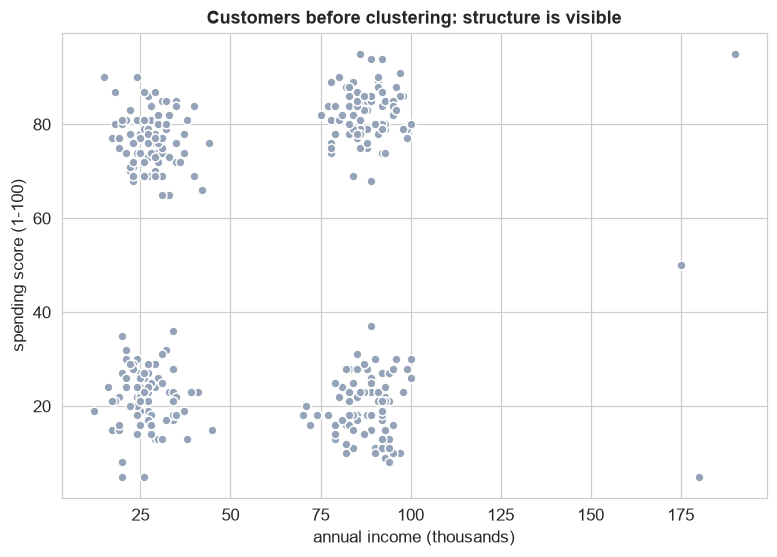

```python
fig, ax = plt.subplots(figsize=(7.2,5.2))
ax.scatter(X['annual_income_k'], X['spending_score'], s=34, c=GREY, edgecolor='white')
ax.set(xlabel='annual income (thousands)', ylabel='spending score (1-100)', title='Customers before clustering: structure is visible')
plt.tight_layout(); plt.show()
```

**Explore first.** Even with no labels, a scatter of income against spending shows four obvious clumps near the corners of the plane, low and high income each splitting by whether the customer spends freely or sparingly. Clustering will make this intuition precise and repeatable across all four dimensions at once (the eye can only see two). Always look before you compute.

DEMO 3 · K-MEANS

Partition into k round clusters

K-means places k centroids and assigns each point to its nearest.

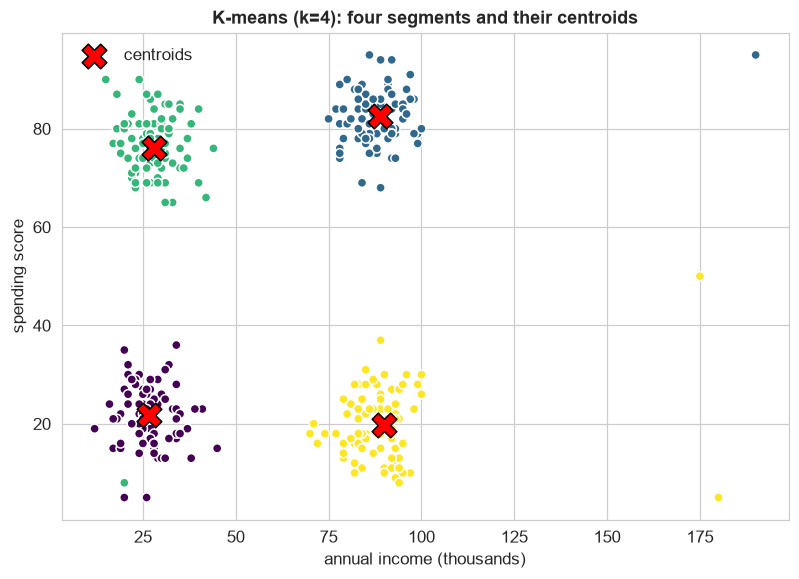

```
cluster sizes:
kmeans
0    85
1    81
2    82
3    82
```

```python
km = KMeans(n_clusters=4, n_init=10, random_state=0).fit(Xs)
df['kmeans'] = km.labels_
cent = StandardScaler().fit(X).inverse_transform(km.cluster_centers_)   # centroids back in original units
fig, ax = plt.subplots(figsize=(7.4,5.4))
ax.scatter(X['annual_income_k'], X['spending_score'], c=km.labels_, cmap='viridis', s=36, edgecolor='white')
ax.scatter(cent[:,0], cent[:,1], c='red', s=260, marker='X', edgecolor='black', label='centroids')
ax.set(xlabel='annual income (thousands)', ylabel='spending score', title='K-means (k=4): four segments and their centroids'); ax.legend()
plt.tight_layout(); plt.show()
print('cluster sizes:'); print(df['kmeans'].value_counts().sort_index().to_string())
```

**How K-means works.** It picks `k` cluster centers, assigns every point to its nearest center, moves each center to the mean of its members, and repeats until nothing moves. It is fast and scales well, but it assumes clusters are **roughly round and similar in size**, and you must choose `k` in advance. The red X's are the final centroids, the average customer of each segment. Next we justify why `k=4` was the right choice.

DEMO 4 · CHOOSING k

Elbow and silhouette

Two ways to pick k when you cannot see 4 dimensions.

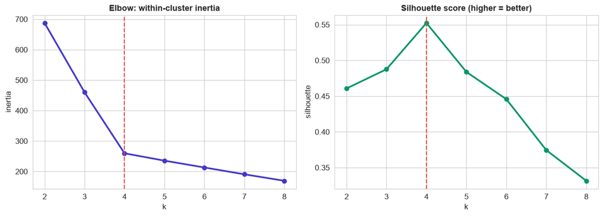

```
best k by silhouette = 4 | score = 0.552
```

```python
ks = range(2, 9)
inertia = [KMeans(n_clusters=k, n_init=10, random_state=0).fit(Xs).inertia_ for k in ks]
sil = [silhouette_score(Xs, KMeans(n_clusters=k, n_init=10, random_state=0).fit_predict(Xs)) for k in ks]
fig, ax = plt.subplots(1, 2, figsize=(12,4.4))
ax[0].plot(list(ks), inertia, 'o-', color=EM, lw=2.4); ax[0].set(title='Elbow: within-cluster inertia', xlabel='k', ylabel='inertia')
ax[0].axvline(4, color=RED, ls='--')
ax[1].plot(list(ks), sil, 'o-', color=GREEN, lw=2.4); ax[1].set(title='Silhouette score (higher = better)', xlabel='k', ylabel='silhouette')
ax[1].axvline(4, color=RED, ls='--'); plt.tight_layout(); plt.show()
print('best k by silhouette =', list(ks)[int(np.argmax(sil))], '| score =', round(max(sil),3))
```

**Two diagnostics agree.** The **elbow** plot shows inertia (total within-cluster distance) always falling as `k` grows, but the *rate* of improvement bends sharply at `k=4`, adding more clusters barely helps. The **silhouette** score measures how well-separated the clusters are (how much closer each point is to its own cluster than to the next-nearest); it peaks at `k=4`. When the elbow and the silhouette point to the same number, you can trust it.

DEMO 5 · HIERARCHICAL CLUSTERING

A dendrogram, no k required up front

Merge the two nearest groups, over and over, into a tree.

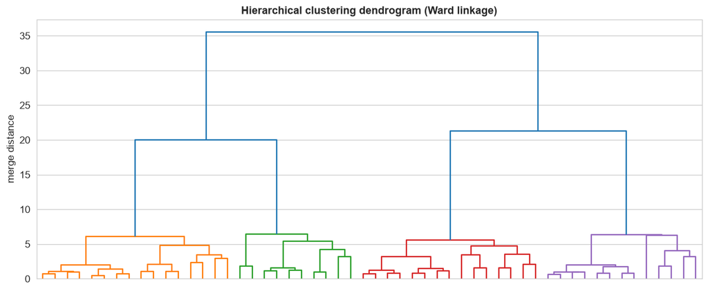

```
agglomerative vs k-means agreement (crosstab):
col_0    0   1   2   3
kmeans
0        0   0   0  85
1        0  81   0   0
2        0   0  82   0
3       82   0   0   0
```

```python
Z = linkage(Xs, method='ward')      # ward = merge the pair that least increases variance
fig, ax = plt.subplots(figsize=(11,4.6))
dendrogram(Z, truncate_mode='level', p=5, no_labels=True, color_threshold=Z[-3,2], ax=ax)
ax.set(title='Hierarchical clustering dendrogram (Ward linkage)', ylabel='merge distance')
plt.tight_layout(); plt.show()
agg = AgglomerativeClustering(n_clusters=4).fit(Xs)
print('agglomerative vs k-means agreement (crosstab):'); print(pd.crosstab(df['kmeans'], agg.labels_))
```

**A tree of nested groups.** Hierarchical clustering starts with every point alone and repeatedly merges the two closest groups, recording the whole history as a **dendrogram**. Cutting the tree at a chosen height gives you the clusters, the tall vertical gaps show where the natural cut is (here, four branches). Unlike K-means it needs no `k` up front and is deterministic, though it is slower on large data. The crosstab shows it recovers essentially the same four segments K-means found.

DEMO 6 · DBSCAN

Density-based: finds odd shapes AND outliers

No k, no assumption of round clusters, and it flags noise.

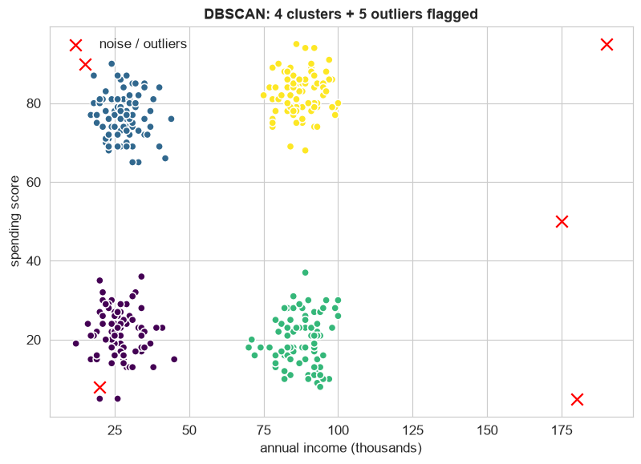

```
DBSCAN found 4 dense clusters and flagged 5 points as noise (label -1)
```

```python
dbs = DBSCAN(eps=0.85, min_samples=6).fit(Xs)
df['dbscan'] = dbs.labels_
n_clusters = len(set(dbs.labels_)) - (1 if -1 in dbs.labels_ else 0)
n_noise = int((dbs.labels_ == -1).sum())
fig, ax = plt.subplots(figsize=(7.4,5.4))
mask = dbs.labels_ == -1
ax.scatter(X['annual_income_k'][~mask], X['spending_score'][~mask], c=dbs.labels_[~mask], cmap='viridis', s=36, edgecolor='white')
ax.scatter(X['annual_income_k'][mask], X['spending_score'][mask], c='red', s=90, marker='x', label='noise / outliers')
ax.set(xlabel='annual income (thousands)', ylabel='spending score', title=f'DBSCAN: {n_clusters} clusters + {n_noise} outliers flagged'); ax.legend()
plt.tight_layout(); plt.show()
print(f'DBSCAN found {n_clusters} dense clusters and flagged {n_noise} points as noise (label -1)')
```

**Density, not centroids.** DBSCAN grows clusters from dense regions: a point with at least `min_samples` neighbors within radius `eps` seeds a cluster, and sparse points left over are labeled **noise** (-1). Its superpowers: it discovers the number of clusters on its own, handles non-round shapes, and, uniquely here, **flags outliers** instead of forcing every point into a group. The price is sensitivity to `eps`, too small and everything is noise, too large and clusters merge. It cleanly isolates the oddball customers K-means had to absorb.

DEMO 7 · PROFILING

From cluster ID to business meaning

A cluster is useless until you can name it.

```
        annual_income_k  spending_score   age  web_visits_mo   n
kmeans
0                  26.7            21.8  39.1            9.8  85
1                  89.0            82.5  42.2           25.5  81
2                  28.0            76.1  28.2           28.2  82
3                  90.0            19.7  49.2            8.3  82
```

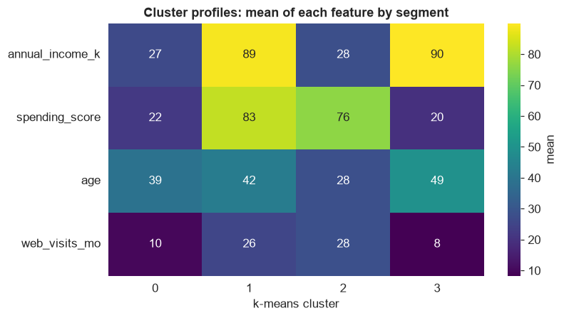

```python
profile = df.groupby('kmeans')[feat].mean().round(1)
profile['n'] = df['kmeans'].value_counts().sort_index()
print(profile.to_string())
fig, ax = plt.subplots(figsize=(7.6,4.2))
sns.heatmap(df.groupby('kmeans')[feat].mean().T, annot=True, fmt='.0f', cmap='viridis', cbar_kws={'label':'mean'}, ax=ax)
ax.set(title='Cluster profiles: mean of each feature by segment', xlabel='k-means cluster'); plt.tight_layout(); plt.show()
```

**The payoff.** Grouping by cluster and averaging each feature turns anonymous labels into a **marketing strategy**: a low-income high-spending 'Young Spenders' group that browses heavily, a high-income high-spend 'Premium' group to nurture, a high-income low-spend 'Savers' group to win over, and a low-income low-spend 'Budget-Conscious' group. This profiling step, describing each cluster in plain business terms, is what makes clustering actionable. The algorithm finds the groups; you give them meaning.

## Clustering, in one view

- **Always standardize** first, distance-based methods are dominated by the largest-scale feature otherwise.
- **K-means**: fast, assumes round equal-size clusters, you choose k (use the **elbow** and **silhouette** together).
- **Hierarchical**: a dendrogram of nested groups, no k up front, deterministic, slower on big data.
- **DBSCAN**: density-based, discovers k itself, handles odd shapes, and flags **outliers** as noise.
- **Profiling** each cluster's feature means is what turns unlabeled groups into decisions.

Statistics, Data Science and AI: A Visual Handbook · © 2026 John Fisher

←Back to the bookChapter 114 · Clustering